# Can we trust AutoML to go on full autopilot?

*We put an AutoML tool to a test on a real-world problem - the results surprised us! The good news is you still need expert data scientists even with AutoML.*

## The Promise of AutoML

Data scientists are in short supply and Automatic Machine Learning (AutoML) promises to alleviate this problem. [H2O Driverless AI](https://www.h2o.ai/products/h2o-driverless-ai/) employs the techniques of expert data scientists in an easy to use application that helps scale your data science efforts. It lets “everyone develop trusted machine learning models”.

## The Experiment

A Chief Data Scientist and four Columbia University students with varying levels of experience put the technology to a test on a real-word problem predicting stock price movements (a challenging task!).

**The special feature of the data is that it is panel data in which there is high cross-sectional correlation between observations on a given day. Furthermore there is high auto correlation across time because input data is provided monthly but target returns are 12 months out so 11/12 months are the same between 2 subsequent observations.**

## Naive Baseline

Before evaluating a model, you need to have a naive baseline as discussed in [Top 10 Statistics Mistakes Made by Data Scientists](https://www.kdnuggets.com/2019/06/statistics-mistakes-data-scientists.html). The first baseline is predicting a 0 return for all observations which is close to the median, meaning there is no way of predicting returns. The second baseline is to rank all features and average them, meaning all features are equally important in forecasting returns (this does not generate return forecasts but you can still compare input and output ranks). The last baseline is the return from a month ago - given the nature of the dataset this includes forward looking information and is a good baseline for assessing any overtraining and look-ahead bias.

Success Metrics for Naive Baseline

| model | MAE | Correl |
| --- | --- | --- |
| 0 return forecast | 0.145 | NaN |
| factor equal-weight | NaN | 0.009 |
| return 1 month ago | 0.222 | 0.238 |

## First hurdle - Technical Setup

Before we got to modeling, the first hurdle was to get everyone set up with DAI. H2O recommends installing Driverless AI on modern data center hardware with GPUs, CUDA support and 64GB RAM. We followed the instructions and installed the software on Google Cloud Platform with the recommended settings.

**The result**: we burned through $200 of GCP credits in less than a week! We soon realized that such high computation power is not required as our dataset was just 1GB in size. We installed Driverless AI on a GCP machine with much lesser specifications and it also worked on a local laptop machine with just 8GB RAM. Overall, the installation of Driverless AI required some amount of technical expertise that not everyone on the team had.

## Second hurdle - Data Preprocessing

The next hurdle was to get the data ready for analysis, AutoML does not help that. We had to preprocess and combine data from multiple data sources which was a substantial effort. We used data workflow library d6tflow and data sharing library d6tpipe from [Top 10 Coding Mistakes Made by Data Scientists](https://www.kdnuggets.com/2019/04/top-10-coding-mistakes-data-scientists.html) to help us with the pre-modeling steps.

**The result**: The preprocessing d6tflow DAG is shown below. It takes stock return data from Bloomberg and stock factors data from WRDS, combines, cleans and normalized both data sources to make it suitable for machine learning in DAI which requires clean data all in one place.

```python
└─--[TaskFactorComposite-{'idx': 'RIY Index', 'dt_start': '2011-01-01', 'dt_end': '2018-09-01'} (PENDING)]
   └─--[TaskFactorsIdx-{'idx': 'RIY Index', 'dt_start': '2011-01-01', 'dt_end': '2018-09-01'} (PENDING)]
      └─--[TaskFwdRtn-{'idx': 'RIY Index', 'dt_start': '2011-01-01', 'dt_end': '2018-09-01'} (PENDING)]
         └─--[TaskBbgHistory-{'idx': 'RIY Index', 'dt_start': '2011-01-01', 'dt_end': '2018-09-01'} (PENDING)]
            └─--[TaskBbgMembers-{'idx': 'RAY Index'} (PENDING)]
```

## Running fully automatic - too good to be true?

In the beginning of our experiment, we worked directly with the driverless AI interface, uploaded datasets, selected target variable, adjusted the knobs for performance, interpretability etc. We must say, the UI is neat and it kind of resembles Tony Stark’s JARVIS. While the total data science newbies struggled with choosing the right settings, the team members with at least an intermediate level of data science knowledge easily knew what to do.

Once the launch button is hit, true to its name, the training was driverless. We watched the progress as it churned out hundreds of models and created thousands of new features and finally created a neat PDF report of the experiment results.

**The result**: MAE of 4% and correlation 96%. WOW! The machine really is better than the human, blowing the naive model out of the water. But it even beat the naive model with look-ahead bias - suspicious!

## Adding realistic test sets manually

Following the out-sample testing advice for panel data in [Top 10 Statistics Mistakes Made by Data Scientists](https://www.kdnuggets.com/2019/06/statistics-mistakes-data-scientists.html), we built our own train/validation/test sets. DAI did not seem to have any functionality to do that so we had to do it manually. We split the data by time and also did rolling forward tests. The skill bar to do this had risen to intermediate.

**The result**: MAE of 6% and correlation 90%. Still way higher than naive model with forward looking bias - suspicious again!

## What does this thing do anyways??

It this point we were not too sure what was driving this exceptional performance, clearly it was too good to be true. We got a report with all technical details and visuals. But how did it build models? What went on behind the closed curtains? It is difficult to understand what it tried. What parameters, what features does it engineer? What features engineered that subsequently dropped out? Not only the newbies got lost here but the pros too.

By carefully analyzing the output we figured out what the problem was: DAI automatically adds lagged variables and out of fold means. Given the nature if our dataset, it being panel data with overlapping target variables, those features caused the look-ahead bias and substantially inflated results.

The graph below illustrates the particular issue in more detail. Assume there are only two stocks: A and B. We want to forecast yearly returns from input data which updates monthly. In training it is easy to forecast A2 from A1 because of the large overlap. But when running the model live we don’t have the same input data, as illustrated by A13 and A14. So we have to be careful with prior observations in training. Also if B is highly correlated with A it is easy to forecast but again that data is not available when the model runs live in production and therefore the exceptional “test” performance would not hold up. These issues also trip up human data scientists as illustrated in more detail with examples in [Top 10 Statistics Mistakes Made by Data Scientists](https://www.kdnuggets.com/2019/06/statistics-mistakes-data-scientists.html), see #7+8.

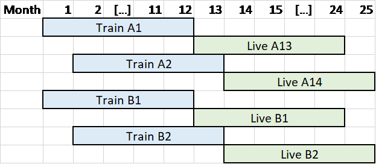

## Going fully manual to avoid look-ahead bias

We had to dig deep into the DAI documentation and use the DAI python client to turn off those features and manually run every experiment to perform a roll-forward analysis with non-overlapping periods. With quite some effort we built a fully automated machine learning workflow using d6tflow optimized for DAI. The skill bar to do this was now at professional.

## Conclusions

First, DAI claims it does not overfit but it did! Driverless AI showed inflated test performance that we would have never achieved running the model in production real-time. This serves as an case study where AutoML systems can give overly optimistic results out-sample is not carefully analyzed. This could be due to unique nature of our dataset but if it happened to us, it could happen to others. Therefore, it is crucially important to understand the characteristics of your data, the type of predictions you make and effective out-sample testing.

Second, the whole data pipeline involved a lot more than just AutoML model training. We needed to prepare data, generate test datasets, manually control DAI via python, and extract outputs to compare with naive models. We still had to know how to use pandas, d6tpipe, d6tflow and DAI python to run the full ML pipeline.

Third, despite transparency for the the ultimate model, it was still unclear what features DAI generated and how it trained models, so it would be difficult for a novice to explain the methodology and output with confidence.

In summary, AutoML systems like H2O Driverless still need an educated data scientist to use, control, interpret and explain the machine learning system. We liken it to flying airplanes: just because an airplane has an autopilot, that does not mean any odd passenger is able to safely operate the airplane and put the trust of 200 lives in their hands without having adequate training.